# Phylogenetics: Theory and Overview

Speciation Genomics · PB 495/595 Plant Evolutionary Biology

George P. Tiley

5 October 2026

# Phylogenetics

## Summary

- We’ve extensively discussed population structure, but now we want to capture the history of shared ancestry among populations and species.
- A phylogenetic tree is a **hypothesis** of shared ancestry, estimated from characters (usually DNA) **under an explicit model**.
- **Today:** the likelihood of a tree from first principles, models of sequence evolution, model selection and ML.
- **Thursday:** the **multispecies coalescent**, species-tree estimation, coalescent species delimitation, and introgression.

## Learning objectives

By the end you should be able to:

- Read a phylogeny (tips, nodes, branch lengths, rooting, clades) and define **homology**.
- Distinguish **probability** from **likelihood**, and explain why programs report $\log L$.
- Compute the likelihood of one site on a small tree.
- Explain **rate variation** among sites (partitions, $+\Gamma$) and choose a model with **AIC/BIC**.

## Why molecular phylogenies?

- **Taxonomy** — today’s angiosperm classification is built on them (The Angiosperm Phylogeny Group 2016).
- **Trait evolution** — how often C<sub>4</sub> photosynthesis evolved in grasses (Grass Phylogeny Working Group II 2012); how baobab pollination syndromes changed (right).
- **Divergence times** — the pace of the angiosperm radiation (Magallón et al. 2015).
- **Biogeography** — baobabs live in Africa, Madagascar *and* Australia.

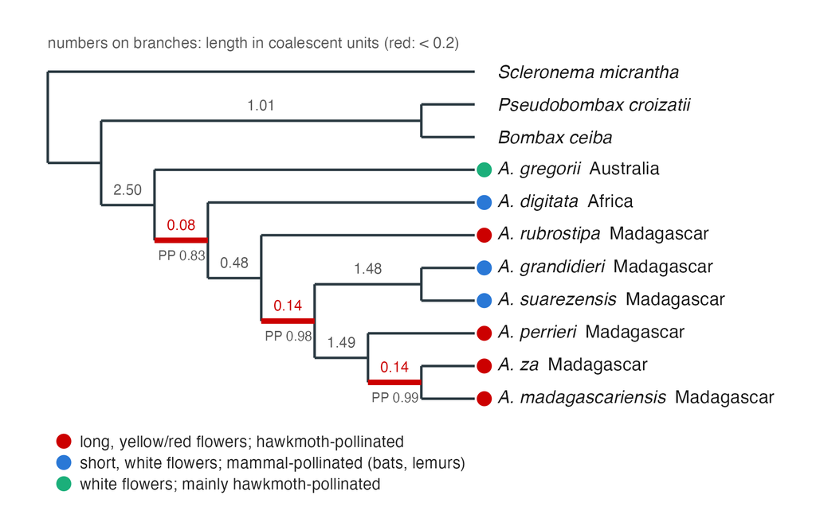

Baobabs: ASTRAL tree from 357 nuclear gene trees; data and traits from Karimi et al. (2020).

# Tree thinking

## Anatomy of a phylogeny

- **Tips** (leaves) = sampled taxa; **internal nodes** = inferred common ancestors.
- **Branch lengths** = expected substitutions/site (or, once dated, time).
- **Clade** = an ancestor + all its descendants (**monophyletic**).
- **Homology**: similarity by common descent — the signal; **homoplasy** (convergence/reversal) is the noise.

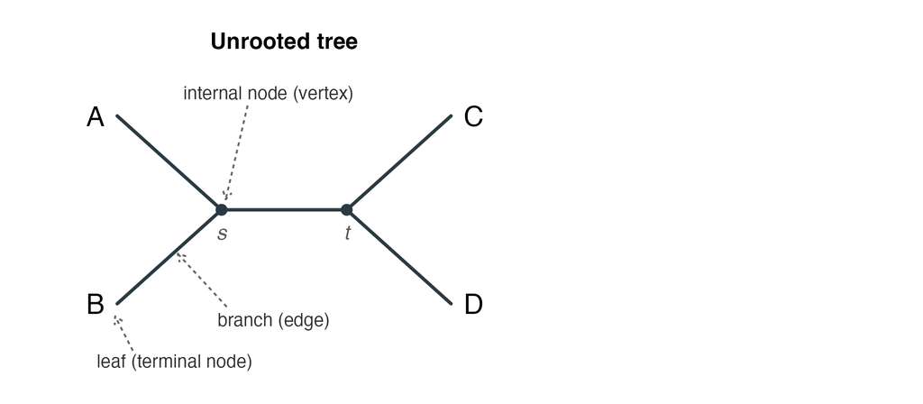

## Rooting gives time a direction

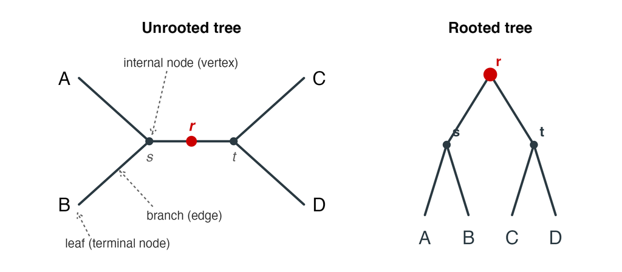

Placing a root **r** on the internal branch gives one rooted tree: $((A,B),(C,D))$.

## Same unrooted tree, different root

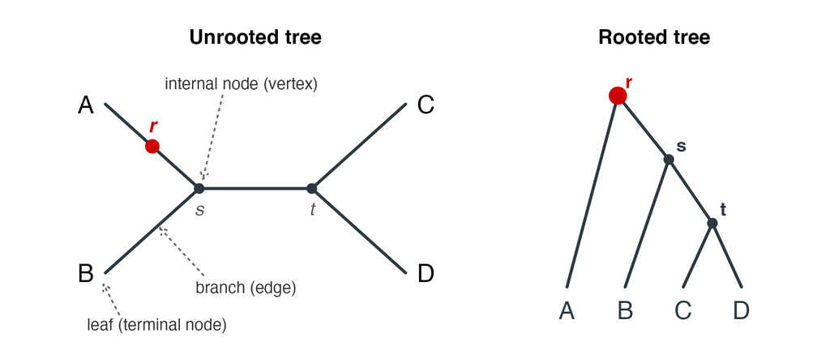

Root on the branch to A instead and the same unrooted tree reads $(A,(B,(C,D)))$. An unrooted four-taxon tree has **five** branches, so **five** possible rootings — the **outgroup** picks one.

## The inference pipeline

From sequences to a supported tree — model choices enter at every step:

1. **Homology / alignment** — orthology assessment, multiple sequence alignment.
2. **Model** — a substitution model (partitions, rate variation).
3. **Search / inference** — optimize or sample trees (ML, Bayesian).
4. **Support** — bootstrap or posterior probabilities.

## Distance & parsimony

- **Distance methods** (e.g. neighbor-joining): reduce sequences to pairwise distances, build a tree by clustering. Fast, but limitations beyond populations or closely related species.
- **Parsimony**: choose the tree minimizing the number of changes. Intuitive, but can fail under various scenarios such as high rates of evolution (“long-branch attraction”).
- Parsimony built the first broad molecular trees of plants: 475 and 499 seed-plant sequences of the plastid gene *rbcL* (Chase et al. 1993).

## Neighbor-joining by hand: where distances come from

Toy alignment: 5 taxa, 17 sites.

```
A  GAACCGGTTACGGGTCT
B  GAACCCAGTAGGGGGCT
C  AGCGCGGGTCCGAGGCG
D  GACGAGGGGCCAGGGGT
E  GACGCGGGGCCAGTGCT
```

The **distance** between two sequences is simply **how many sites differ**:

```
A  GAACCGGTTACGGGTCT
B  GAACCCAGTAGGGGGCT
        ***  *   *     <- 5 sites differ
```

So $d(A,B)=5$. In real data we divide by the alignment length and correct for sites that changed more than once (the Jukes–Cantor correction, later in this deck). In this toy every change happened once, so a plain count is enough.

## The distance matrix

Counting differences for all 10 pairs gives one table:

|  | **A** | **B** | **C** | **D** | **E** | **Total** |
| --- | --- | --- | --- | --- | --- | --- |
| **A** | – | 5 | 9 | 9 | 8 | 31 |
| **B** | 5 | – | 10 | 10 | 9 | 34 |
| **C** | 9 | 10 | – | 8 | 7 | 34 |
| **D** | 9 | 10 | 8 | – | 3 | 30 |
| **E** | 8 | 9 | 7 | 3 | – | 27 |

**Total** = add up a row: how far that taxon is from all the others.

**Goal:** a tree whose branch lengths, added along the path between two tips, give back these distances.

**Plan:** find two taxa that are **neighbors** (they sit next to each other on the tree), merge them into one new node, shrink the table, and repeat.

## Which pair are neighbors?

The closest pair is not always the right one. Two taxa can look close just because *everyone* is close to everyone, or look far apart just because each sits on a long branch. So NJ adjusts each distance for how far the two taxa are from the **rest**:

$$\text{score}(i,j) = (n-2)\times d(i,j) - \text{total}(i) - \text{total}(j)$$

Here $n$ is the number of taxa still in the table (5 now, so $n-2=3$). The **lowest score wins**: a small distance helps, and so does being far from everyone else.

| Pair | Distance | Totals | Score |
| --- | --- | --- | --- |
| D–E | 3 | 30, 27 | $3\times3-30-27=-48$ |
| A–B | 5 | 31, 34 | $3\times5-31-34=\mathbf{-50}$ |

D–E is the closest pair, but A and B are each much farther from C, D and E than from each other, so A–B scores lower.

## Step 1: score every pair

**Distances**

|  | **A** | **B** | **C** | **D** | **E** |
| --- | --- | --- | --- | --- | --- |
| **A** | – | 5 | 9 | 9 | 8 |
| **B** | 5 | – | 10 | 10 | 9 |
| **C** | 9 | 10 | – | 8 | 7 |
| **D** | 9 | 10 | 8 | – | 3 |
| **E** | 8 | 9 | 7 | 3 | – |

**Scores** ($3d-\text{totals}$)

|  | **A** | **B** | **C** | **D** | **E** |
| --- | --- | --- | --- | --- | --- |
| **A** | – | **−50** | −38 | −34 | −34 |
| **B** | **−50** | – | −38 | −34 | −34 |
| **C** | −38 | −38 | – | −40 | −40 |
| **D** | −34 | −34 | −40 | – | −48 |
| **E** | −34 | −34 | −40 | −48 | – |

Totals: A 31, B 34, C 34, D 30, E 27. For example, A–C: $3\times9-31-34=-38$.

The lowest score is A–B ($-50$): **join A and B** into a new node, **u**.

## Step 1: how long are the branches to A and B?

A and B are 5 apart, so (A’s branch) + (B’s branch) = 5. How do we split it?

Every path from A or B to any other taxon goes through $u$. So if B is farther from the others than A is, the extra distance must be on **B’s own branch**.

- Totals: A = 31, B = 34. B is 3 farther in total.
- Both totals include the A–B distance, so the 3 extra comes from the other **3** taxa: $3 \div 3 = 1$ extra per taxon.
- So **B’s branch is 1 longer than A’s**, and the two add to 5:

$$\text{A's branch} = 2, \qquad \text{B's branch} = 3$$

In one line: $\text{A's branch} = \tfrac12\left[d(A,B) + \dfrac{\text{total}(A)-\text{total}(B)}{n-2}\right] = \tfrac12\left[5 + \dfrac{31-34}{3}\right] = 2$

## Step 1: distances from the new node

How far is $u$ from C? Both A and B give an answer: take their distance to C and remove their own branch.

- From A: $d(A,C) - 2 = 9 - 2 = 7$
- From B: $d(B,C) - 3 = 10 - 3 = 7$

The two agree (they always do when distances come from a tree). The same for D and E:

|  | via A | via B | $u$ to it |
| --- | --- | --- | --- |
| C | 9 − 2 = 7 | 10 − 3 = 7 | **7** |
| D | 9 − 2 = 7 | 10 − 3 = 7 | **7** |
| E | 8 − 2 = 6 | 9 − 3 = 6 | **6** |

A and B are now replaced by $u$ (distances among C, D, E don’t change):

|  | **u** | **C** | **D** | **E** | **Total** |
| --- | --- | --- | --- | --- | --- |
| **u** | – | 7 | 7 | 6 | 20 |
| **C** | 7 | – | 8 | 7 | 22 |
| **D** | 7 | 8 | – | 3 | 18 |
| **E** | 6 | 7 | 3 | – | 16 |

## Step 2: score every pair again

**Distances**

|  | **u** | **C** | **D** | **E** |
| --- | --- | --- | --- | --- |
| **u** | – | 7 | 7 | 6 |
| **C** | 7 | – | 8 | 7 |
| **D** | 7 | 8 | – | 3 |
| **E** | 6 | 7 | 3 | – |

**Scores** ($2d-\text{totals}$)

|  | **u** | **C** | **D** | **E** |
| --- | --- | --- | --- | --- |
| **u** | – | **−28** | −24 | −24 |
| **C** | **−28** | – | −24 | −24 |
| **D** | −24 | −24 | – | **−28** |
| **E** | −24 | −24 | **−28** | – |

Now $n=4$, so we multiply by $n-2=2$. Totals: u 20, C 22, D 18, E 16. For example, D–E: $2\times3-18-16=-28$.

**A tie:** u–C and D–E both score $-28$. With four nodes they describe the same unrooted tree, so either is fine. We join **D and E** into a new node, **w**.

## Step 2: join D and E

**Branch lengths.** D and E are 3 apart. Their totals are 18 and 16, a difference of 2 spread over the other 2 nodes: $2\div2=1$. So D’s branch is 1 longer than E’s, and they add to 3:

$$\text{D's branch} = 2,\qquad \text{E's branch} = 1$$

**Distances from $w$.** Take a distance and remove the branch:

- To u: $d(D,u)-2 = 7-2 = 5$, and $d(E,u)-1 = 6-1 = 5$ ✓
- To C: $d(D,C)-2 = 8-2 = 6$, and $d(E,C)-1 = 7-1 = 6$ ✓

New table (3 nodes):

|  | **u** | **C** | **w** |
| --- | --- | --- | --- |
| **u** | – | 7 | 5 |
| **C** | 7 | – | 6 |
| **w** | 5 | 6 | – |

## Step 3: the last three nodes

Three nodes can only be joined one way: each hangs off a single central point.

$$(\text{u's branch}) + (\text{C's branch}) = 7,\quad
(\text{u's branch}) + (\text{w's branch}) = 5,\quad
(\text{C's branch}) + (\text{w's branch}) = 6$$

To get C’s branch: add C’s two distances (7 and 6) and subtract the u–w distance (5). That counts C’s branch twice and cancels u’s and w’s, so halve it:

$$\text{C's branch} = \tfrac12(7+6-5) = 4,\qquad
\text{u's branch} = \tfrac12(7+5-6) = 3,\qquad
\text{w's branch} = \tfrac12(5+6-7) = 2$$

Every branch now has a length.

## Neighbor-joining: the result

$$(\,C{:}4,\ (A{:}2,\,B{:}3){:}3,\ (D{:}2,\,E{:}1){:}2\,)$$

Check: add up the branches on the path between two tips and compare with the table.

| Pair | Path | Sum | Table |
| --- | --- | --- | --- |
| A–B | 2 + 3 | 5 | 5 |
| A–C | 2 + 3 + 4 | 9 | 9 |
| A–D | 2 + 3 + 2 + 2 | 9 | 9 |
| A–E | 2 + 3 + 2 + 1 | 8 | 8 |
| B–C | 3 + 3 + 4 | 10 | 10 |

| Pair | Path | Sum | Table |
| --- | --- | --- | --- |
| B–D | 3 + 3 + 2 + 2 | 10 | 10 |
| B–E | 3 + 3 + 2 + 1 | 9 | 9 |
| C–D | 4 + 2 + 2 | 8 | 8 |
| C–E | 4 + 2 + 1 | 7 | 7 |
| D–E | 2 + 1 | 3 | 3 |

All ten match, because these distances came from a tree.

- NJ gives an **unrooted** tree; add a root afterwards using an outgroup.
- It is **greedy**: it takes the best-looking join at each step and never revisits it. No tree is scored, so there is no likelihood and no measure of confidence.
- Real distances are noisy and undercount hidden changes, so the result is only as good as the distance correction.

⟹ This approach is usually appropriate for populations or closely-related species.

# Probability and likelihood

## Two rules of probability

Roll a fair **10-sided** die twice.

**AND** — multiply (independent events)

*A 1 on the first roll **and** a 2 on the second?*

$$\Pr\{1 \text{ and } 2\} = \tfrac{1}{10}\times\tfrac{1}{10} = \tfrac{1}{100}$$

**OR** — add (mutually exclusive events)

*A 1 **or** a 2 on one roll?*

$$\Pr\{1 \text{ or } 2\} = \tfrac{1}{10}+\tfrac{1}{10} = \tfrac{1}{5}$$

Every likelihood on a tree is built from these two rules: **multiply** along a history, **add** over the histories we can’t observe.

## Probability vs likelihood

I rolled **2, 1, 1, 4**. Is that surprising?

$$\Pr\{2,1,1,4 \mid \text{10-sided die}\} = \left(\tfrac{1}{10}\right)^4 = \tfrac{1}{10\,000}$$

Maybe I used a **4-sided** die. Is that less surprising?

$$\Pr\{2,1,1,4 \mid \text{4-sided die}\} = \left(\tfrac{1}{4}\right)^4 = \tfrac{1}{256}$$

The die is the **model**. Probability fixes the model and asks about data; **likelihood** fixes the data and compares models.

## The likelihood function

The likelihood of a model is the probability of the **observed** data under it:

$$\begin{aligned}
L(\text{4-sided die}) &= f(X \mid \text{4-sided die}) = \prod_{h=1}^{N} f(x_h \mid \text{4-sided die}) \\[4pt]
L(\theta) &= f(X \mid \theta) = \prod_{h=1}^{N} f(x_h \mid \theta)
\end{aligned}$$

- $X = (x_1,\dots,x_N)$ are the $N$ observations (for an alignment, its sites); $\theta$ is the model parameters. **Do not confuse with our popgen parameter $\theta$**
- The product is the **AND** rule — observations are assumed independent.
- **Maximum likelihood**: pick the $\theta$ (a combination of many parameters) that makes the observed data least surprising.

## Why programs always report $\log L$

- Tree likelihoods are products of thousands of site probabilities, each $<1$.
- A double-precision number can’t go below about $10^{-308}$; a few thousand sites gets there.
- The product **underflows** to 0. Many computer programs do not store numbers smaller than 16 decimal places.
- So everything is done on the log scale. Throughout, $\log$ means the natural log.

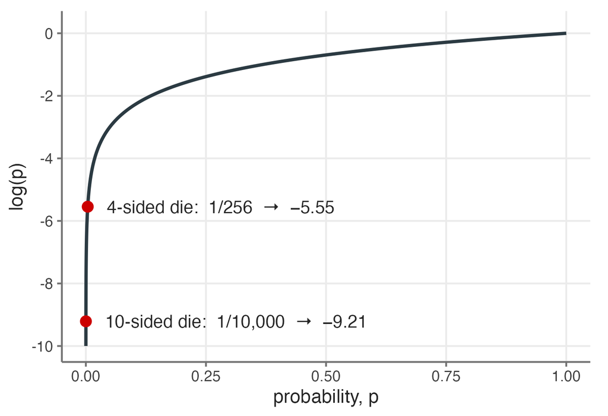

## Logs turn products into sums

$$\log(x\times y) = \log x + \log y \quad\Longrightarrow\quad
\ell(\theta) = \log L(\theta) = \sum_{h=1}^{N}\log f(x_h\mid\theta)$$

| Model | $\Pr\{2,1,1,4\}$ | $\log\Pr$ |
| --- | --- | --- |
| 10-sided die | $1/10\,000$ | $-9.21$ |
| 4-sided die | $1/256$ | $-5.55$ |

The **log-likelihood is maximized** by the model that surprises us the least.

# Likelihood on a tree

## Pretend we know the ancestors

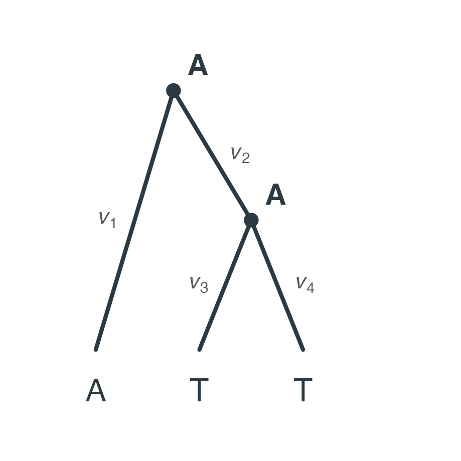

One alignment column: tips **A, T, T**. Suppose both ancestors were **A**. By the **AND** rule:

$$\Pr = \pi_A \cdot P_{AA}(v_1)\cdot P_{AA}(v_2)\cdot P_{AT}(v_3)\cdot P_{AT}(v_4)$$

$P_{ij}(v)$ = probability that state $i$ becomes $j$ along a branch of length $v$.

## The root: $\pi_A$

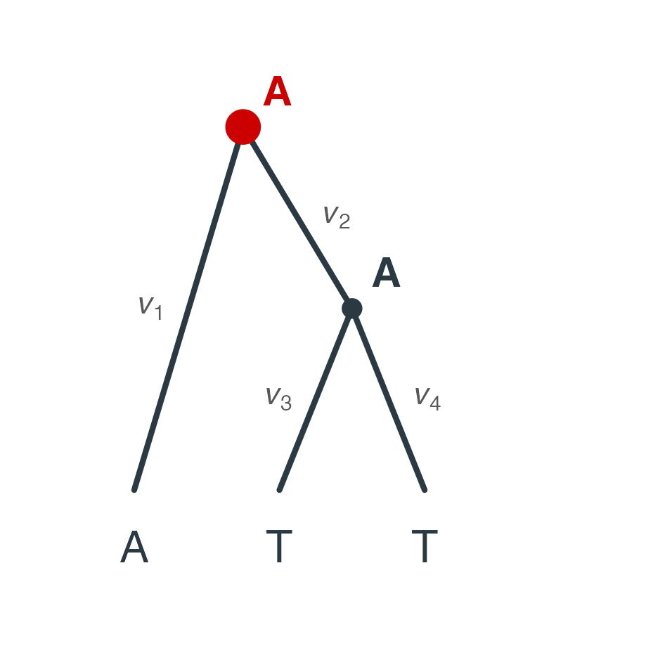

$$\Pr = \bbox[#FBE3E3,3px]{\pi_A} \cdot P_{AA}(v_1)\cdot P_{AA}(v_2)\cdot P_{AT}(v_3)\cdot P_{AT}(v_4)$$

The probability that the root is in state A: the **equilibrium (stationary) frequency** of A.

## Branch $v_1$: root → tip A

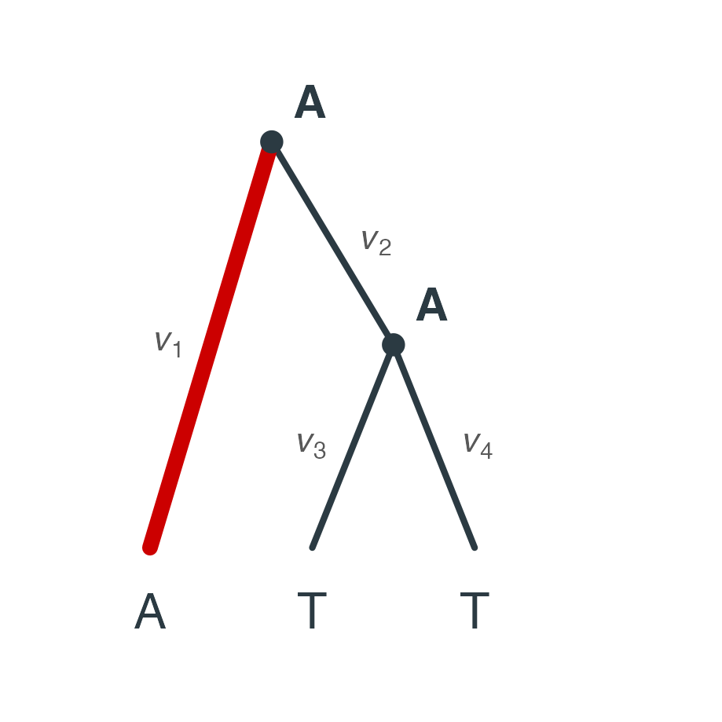

$$\Pr = \pi_A \cdot \bbox[#FBE3E3,3px]{P_{AA}(v_1)}\cdot P_{AA}(v_2)\cdot P_{AT}(v_3)\cdot P_{AT}(v_4)$$

Start as A, still A after $v_1$.

## Branch $v_2$: root → internal node

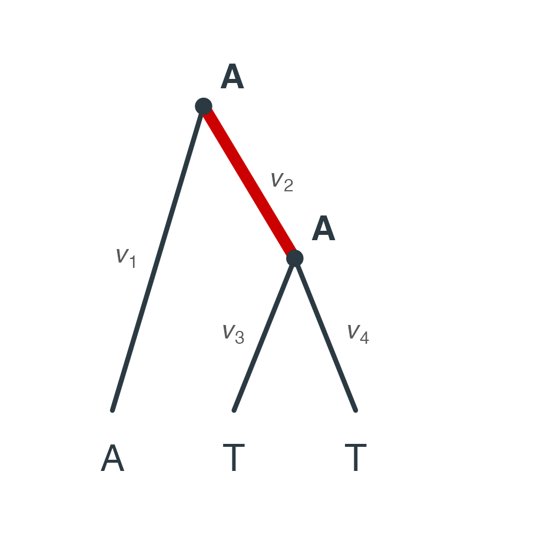

$$\Pr = \pi_A \cdot P_{AA}(v_1)\cdot \bbox[#FBE3E3,3px]{P_{AA}(v_2)}\cdot P_{AT}(v_3)\cdot P_{AT}(v_4)$$

## Branches $v_3$ and $v_4$: A → T, twice

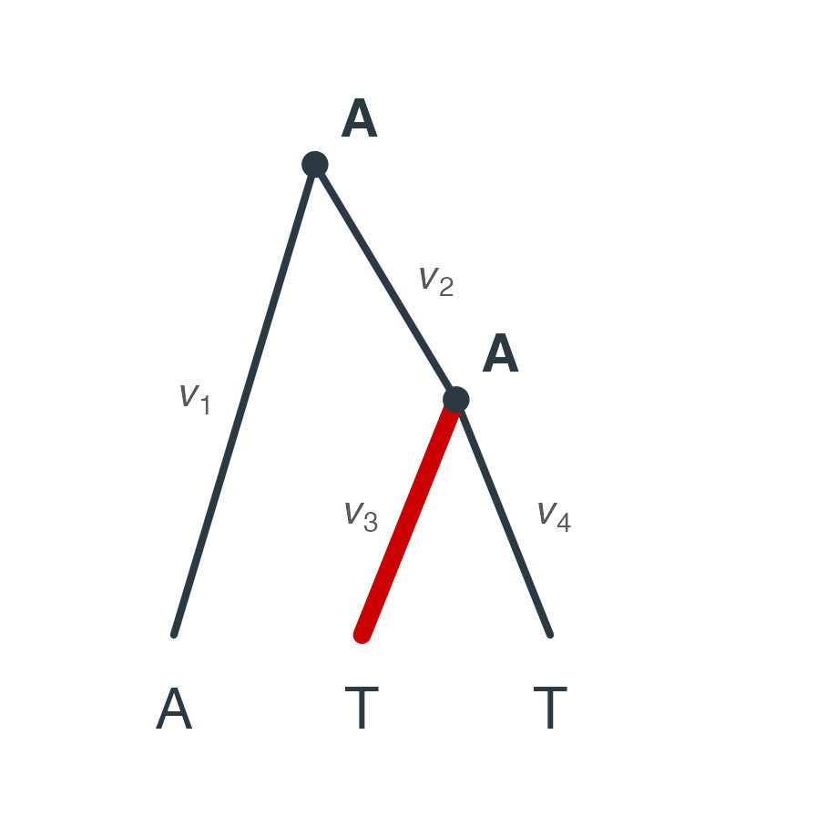

$$\Pr = \pi_A \cdot P_{AA}(v_1)\cdot P_{AA}(v_2)\cdot \bbox[#FBE3E3,3px]{P_{AT}(v_3)}\cdot P_{AT}(v_4)$$

## Two probability components to keep track of

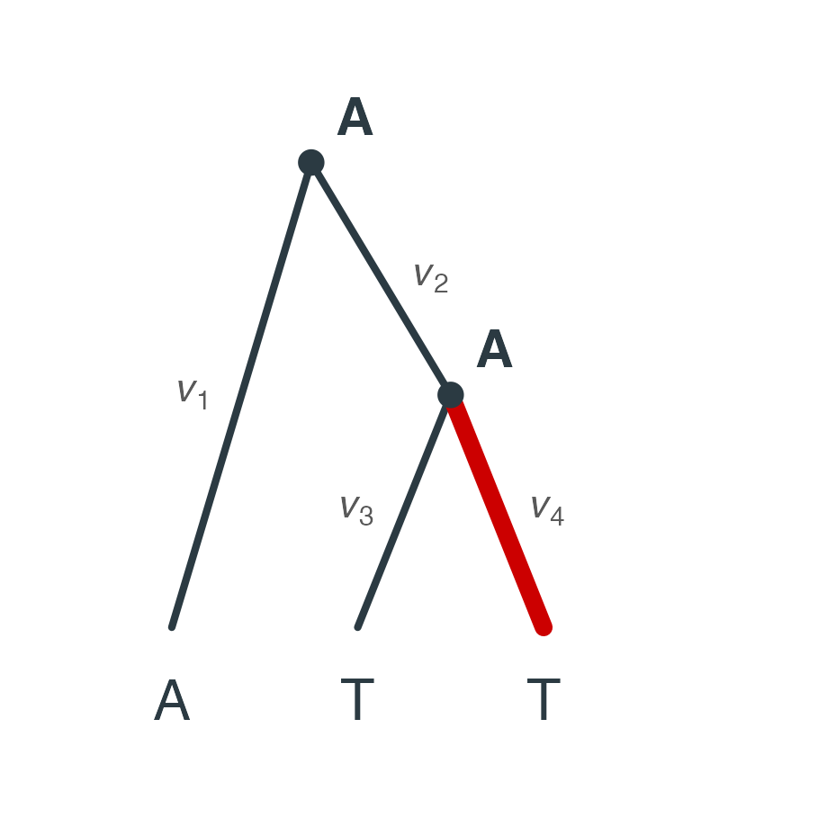

$$\Pr = \underbrace{\pi_A}_{\text{equilibrium}} \cdot
\underbrace{P_{AA}(v_1)\, P_{AA}(v_2)\, P_{AT}(v_3)\, \bbox[#FBE3E3,3px]{P_{AT}(v_4)}}_{\text{transition probabilities}}$$

Both come from the **substitution model**.

## But we never know the ancestors

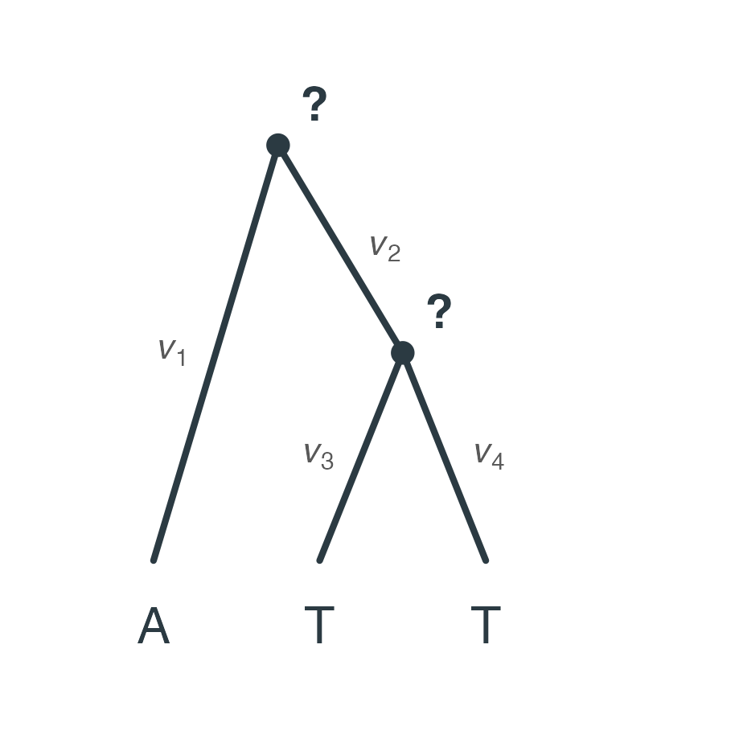

Ancestral states are **unobserved**. So we **add** (the OR rule) over every state they could have had:

$$L = \sum_{x}\sum_{y}\pi_x\,P_{xA}(v_1)\,P_{xy}(v_2)\,P_{yT}(v_3)\,P_{yT}(v_4)$$

$x$ = root state, $y$ = internal-node state, each $\in\{A,C,G,T\}$.

## One term at a time

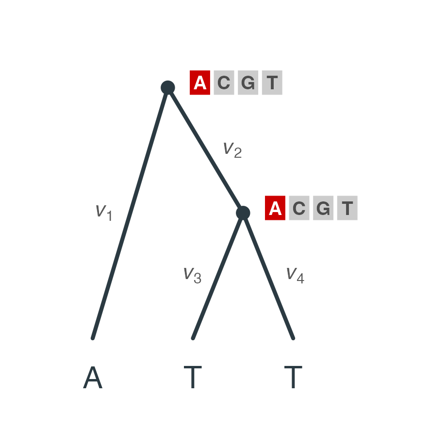

$\pi_A P_{AA}P_{AA}P_{AT}P_{AT}$

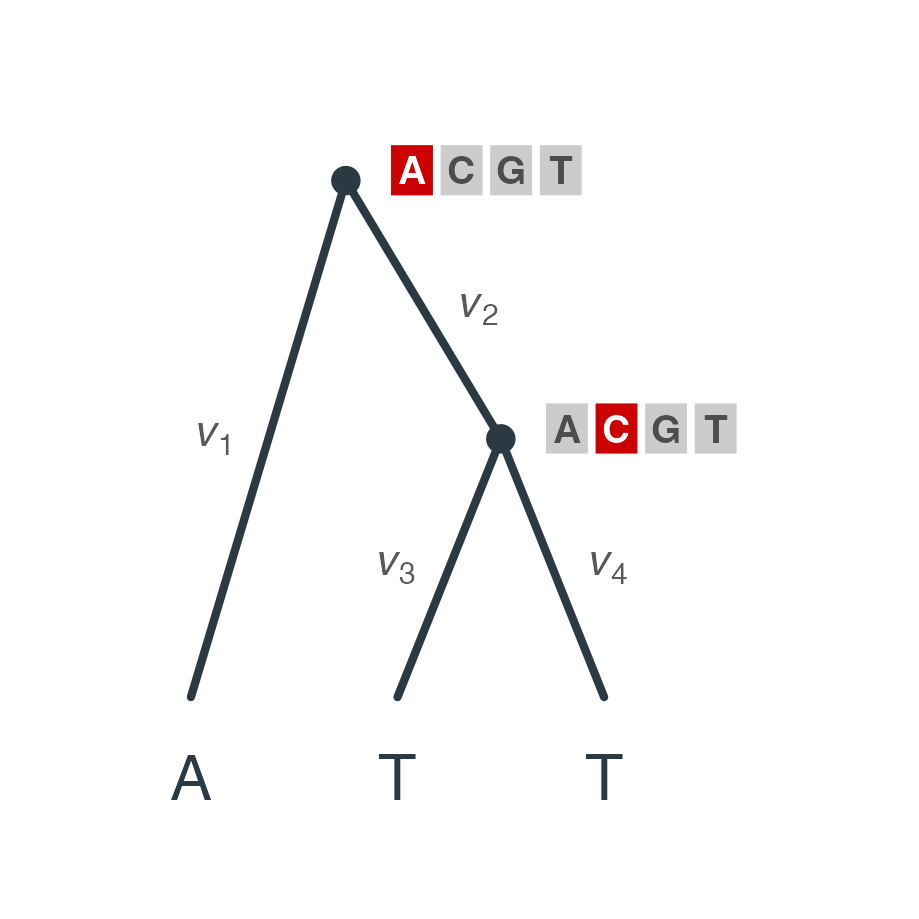

$\pi_A P_{AA}P_{AC}P_{CT}P_{CT}$

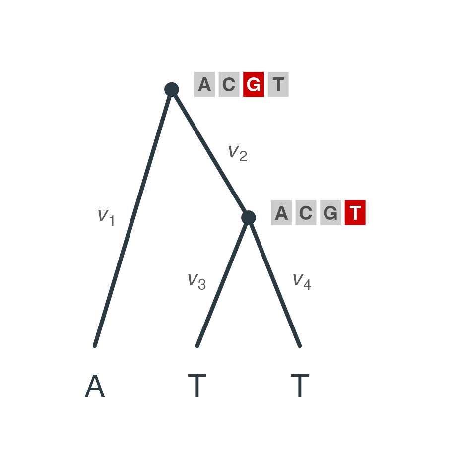

$\pi_G P_{GA}P_{GT}P_{TT}P_{TT}$

Each choice of ancestral states is one history; its probability is a product. The site likelihood is the **sum** over all of them.

## All 16 histories

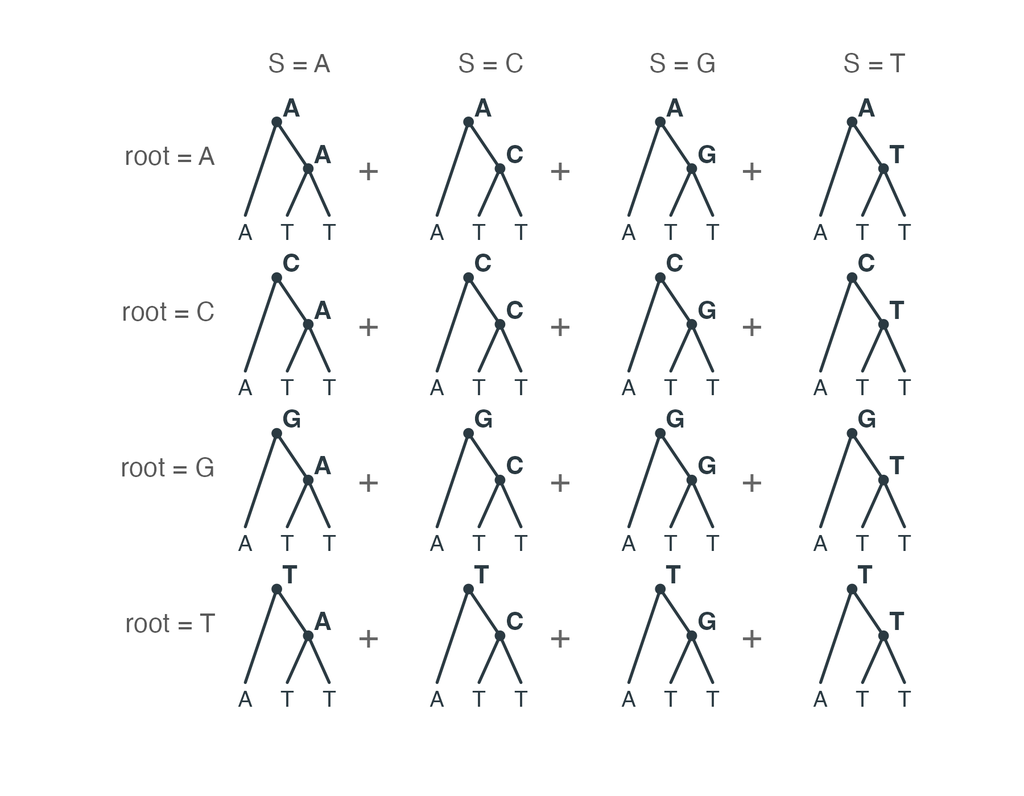

With $n$ tips there are $n-1$ internal nodes, so $4^{\,n-1}$ histories per site: 20 taxa → $4^{19} \approx 2.7\times10^{11}$.

## A lot of repetition

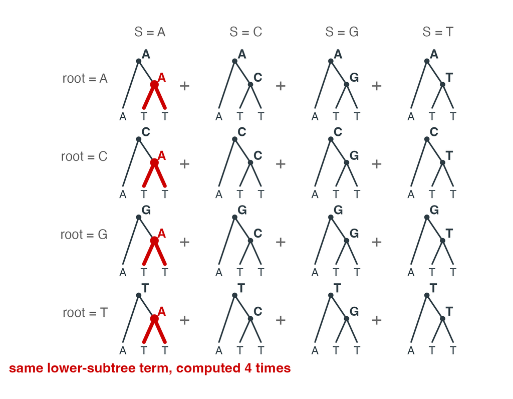

The lower-subtree term $P_{yT}(v_3)P_{yT}(v_4)$ depends only on $y$ — yet it’s recomputed for every root state.

## Pruning: do the repeated part once

Same sum, grouped so the repeated part appears only once ($ab+ac=a(b+c)$):

$$L = \sum_{x}\pi_x\ \underbrace{P_{xA}(v_1)}_{\text{tip 1}}\ \sum_{y}P_{xy}(v_2)\
\underbrace{\big[P_{yT}(v_3)\,P_{yT}(v_4)\big]}_{\text{the two T tips, if the internal node is } y}$$

The bracket depends only on $y$, not on the root state $x$. So compute it **once for each of the 4 values of $y$**, write the 4 numbers down, and reuse them for every root state.

**Pruning does this at every node, from the tips toward the root.** At each node keep a list of 4 numbers $L_k$, one per base:

> $L_k(s)$ = how likely the tips below node $k$ are, **if node $k$ has base $s$**

(its formal name is the *conditional likelihood*).

## Pruning, step 1: start at the tips

A tip’s base is known, so its list is simple: the observed base explains the data perfectly (1), and any other base cannot (0).

Our column, tips **A, T, T**:

| Base | Tip 1 (A) | Tip 3 (T) | Tip 4 (T) |
| --- | --- | --- | --- |
| A | **1** | 0 | 0 |
| C | 0 | 0 | 0 |
| G | 0 | 0 | 0 |
| T | 0 | **1** | **1** |

## Pruning, step 2: move up one node

For **each possible base** at a node, handle the two children separately, then combine:

1. **One child:** the chance the node’s base turns into each possible child base, times that child’s list, **added up** over the child’s bases.
2. **Two children:** **multiply** their answers (given the node’s base, the two sides evolve independently).

**Example: node $S$** (children: tips 3 and 4, both T). If $S$ has base $y$:

- Tip 3: $\sum_x P_{yx}(v_3)\,L_3(x) = P_{yT}(v_3)$, because tip 3’s list is 0 except at T.
- Tip 4: likewise $P_{yT}(v_4)$.
- So $L_S(y) = P_{yT}(v_3)\times P_{yT}(v_4)$: the conditional likelihood we reused above.

In symbols, for any node $k$ with children $i$ and $j$:

$$L_k(s) = \Big[\sum_{x}P_{sx}(v_i)\,L_i(x)\Big]\times\Big[\sum_{x}P_{sx}(v_j)\,L_j(x)\Big]$$

Sum = OR, multiply = AND

## Pruning, step 3: the root, then done

Treat the root $R$ like any other node (children: tip 1 and $S$) to get its list $L_R$. Nothing lies above it, so weight each base by its equilibrium frequency $\pi_s$ and add:

$$L_{\text{site}} = \sum_{s}\pi_s\,L_R(s)$$

**The whole algorithm for one site:**

1. Write the 0/1 lists for the tips.
2. Work upward, node by node, using the step 2 recipe.
3. At the root, weight by $\pi$ and add.

**Cost:** one small calculation per internal node, so it grows with the number of taxa, versus $4^{\,n-1}$ histories by brute force (Felsenstein 1981). Repeat for every site.

## A worked number: the set-up

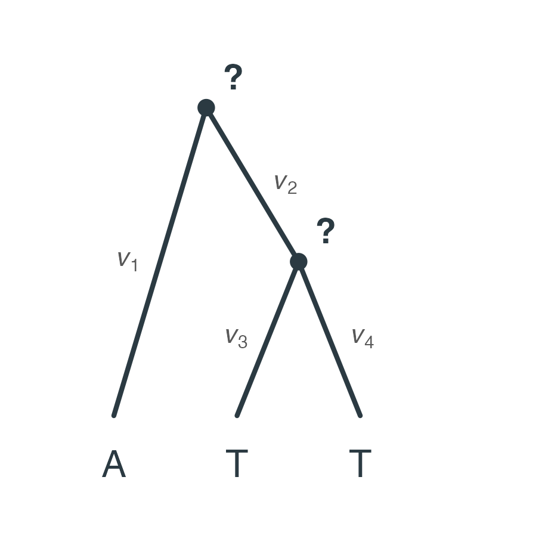

One alignment column: tips **A, T, T**. Call the internal node **S** and the root **R**.

- Branch lengths (expected substitutions per site): $v_1=0.2$, $v_2=v_3=v_4=0.1$.
- Model **JC69**: all four bases equally common ($\tfrac14$ each) and all changes equally likely.

Along a branch, a base either **stays** the same or **changes** to one particular other base:

| Branch length | Chance of **staying** | Chance of **changing** to one specific base |
| --- | --- | --- |
| 0.1 | 0.90638 | 0.03121 |
| 0.2 | 0.82445 | 0.05852 |

Check: 0.90638 + 3 × 0.03121 = 1 (stay, or change to one of the 3 other bases).

## A worked example: node $S$

$S$ has two **T** tips on branches of length 0.1. For each possible state of $S$, how likely are two T tips?

| If $S$ is… | What must happen | Probability |
| --- | --- | --- |
| T | both branches **stay** T | $0.90638^2=\mathbf{0.82152}$ |
| A (or C, or G) | both branches **change** to T | $0.03121^2=0.00097$ |

If $S$ were anything other than T, two separate changes would be needed: about 850 times less likely.

We keep these as a list with one entry per state of $S$:

$$L_S = (A,\ C,\ G,\ T) = (0.00097,\ 0.00097,\ 0.00097,\ 0.82152)$$

## A worked example: node $R$ (the root)

For each possible root state, two things must work out: tip 1 (A, branch 0.2) and the subtree below $S$ (branch 0.1). Multiply the two.

**Root = A.** Tip 1 stays A: 0.82445. For the subtree, add over the possible states of $S$, each weighted by the chance of the root becoming that state:

$$\underbrace{0.90638 \times 0.00097}_{S=A} + \underbrace{0.03121 \times 0.00097}_{S=C} + \underbrace{0.03121 \times 0.00097}_{S=G}
+ \underbrace{0.03121 \times 0.82152}_{S=T}$$

$$= 0.00088 + 0.00003 + 0.00003 + 0.02564 = 0.02658$$

Root = A: $0.82445 \times 0.02658 = 0.02191$. The same recipe gives the other roots:

| Root is | Tip 1 (needs A) | Subtree below $S$ | Product |
| --- | --- | --- | --- |
| A | 0.82445 (stay) | 0.02658 | **0.02191** |
| C | 0.05852 (change) | 0.02658 | **0.00156** |
| G | 0.05852 (change) | 0.02658 | **0.00156** |
| T | 0.05852 (change) | 0.74470 | **0.04358** |

For C and G the subtree term equals A’s (they treat $S$ the same way). For T it is mostly $S=$ T staying T: $0.90638\times0.82152=0.74461$, plus a little from $S=$ A, C, G.

## A worked example: the probability of the whole graph

Each root state is equally likely a priori ($\tfrac14$). Weight the products and add:

$$L = \tfrac14\,(0.02191 + 0.00156 + 0.00156 + 0.04358) = \mathbf{0.01715},
\qquad \log L = -4.066$$

- **Check:** adding up all 16 root/internal-state histories by brute force gives the same number. Pruning is the same sum, organized.
- **Which root state is most plausible?** Each one’s share of the total: T 64%, A 32%, C 2%, G 2%. The two T tips outvote the single A, because tip 1’s branch (0.2) is the longest, so it says the least about the root.
- That was **one site**. An alignment has many sites, and we combine their likelihoods next.

## From one site to an alignment

Sites are assumed independent — the **AND** rule again. $L_h$ is the likelihood of site $h$ (the pruning result):

$$L = \Pr(\text{data}\mid \tau, \text{model}) = \prod_{h=1}^{N} L_h
\qquad\Longrightarrow\qquad
\ell = \sum_{h=1}^{N}\log L_h$$

- **Maximum likelihood (ML)**: find the topology $\tau$, branch lengths and model parameters that maximize $\ell$ (RAxML, IQ-TREE).
- Identical columns (**site patterns**) are computed once and weighted by their counts.

# Models of sequence evolution

## Where do the $P_{ij}(v)$ come from?

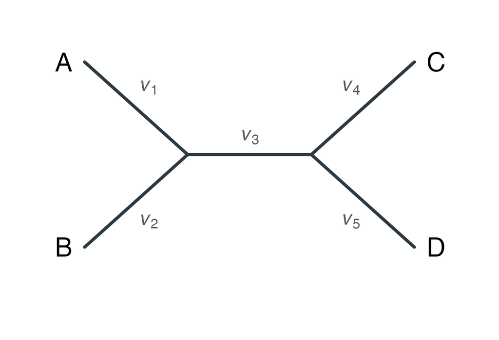

A model needs:

- **Topology and branch lengths** $v_i$, in **expected substitutions per site**.
- A **rate matrix** $Q$ saying how bases change into each other per unit of $v$.

From these two, every $P_{ij}(v)$ follows.

## Branch lengths confound rate and time

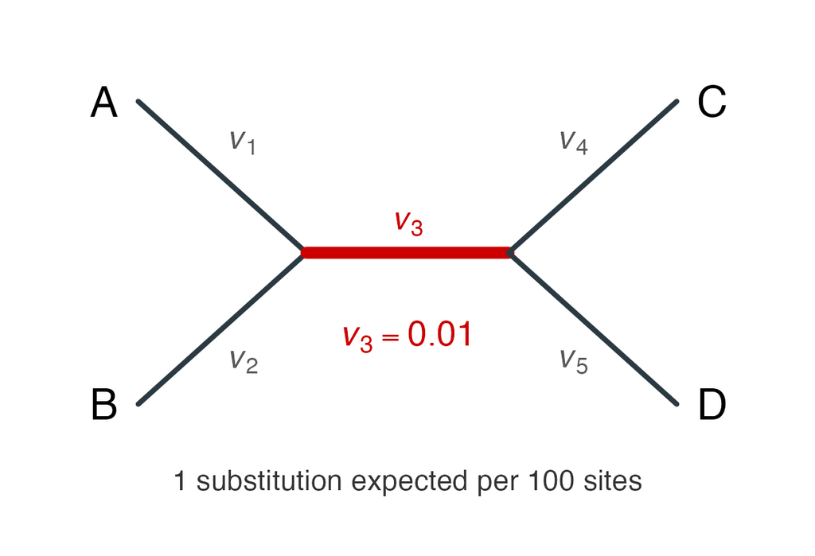

For a 10,000 bp locus:

$$\begin{aligned}
\tfrac{1\ \text{sub}}{1\ \text{My}}\times 100\ \text{My} &= \tfrac{100\ \text{subs}}{10\,000\ \text{bp}} = 0.01\\[4pt]
\tfrac{10\ \text{subs}}{1\ \text{My}}\times 10\ \text{My} &= \tfrac{100\ \text{subs}}{10\,000\ \text{bp}} = 0.01
\end{aligned}$$

Same branch length, a tenfold difference in time. Separating them needs a **clock model**.

## The substitution process is a Markov chain

Model each site as a **continuous-time Markov chain** over states {A, C, G, T}. The **instantaneous rate matrix** $Q$ gives the rate of change from state $i$ to $j$:

$$Q = \{q_{ij}\},\qquad q_{ii} = -\sum_{j\neq i} q_{ij}\ \text{(rows sum to 0)}.$$

The probability of ending in state $j$ after time $t$, starting in $i$:

$$P(t) = e^{Qt}, \qquad P_{ij}(t) = \Pr(j \text{ at } t \mid i \text{ at } 0).$$

- $P(t)$ **averages over all unobserved histories** on a branch — including multiple hits.
- **Markov process**: only the current state matters, not how it got there. Named after Andrey Markov (1856–1922).
- **Time-reversible**: $\pi_i q_{ij} = \pi_j q_{ji}$ — the process looks the same run backwards.

## Jukes & Cantor (1969): the simplest $Q$

$$Q = \begin{array}{c|cccc}
& A & C & G & T\\ \hline
A & -3\lambda & \lambda & \lambda & \lambda\\
C & \lambda & -3\lambda & \lambda & \lambda\\
G & \lambda & \lambda & -3\lambda & \lambda\\
T & \lambda & \lambda & \lambda & -3\lambda
\end{array}$$

- Every change happens at the same rate $\lambda$ (Jukes and Cantor 1969).
- Equilibrium frequencies are equal: $\pi_A=\pi_C=\pi_G=\pi_T=0.25$.
- A leaves A at total rate $3\lambda$, so $q_{AA}=-3\lambda$: the rows sum to 0 and probability is conserved.

## Deriving $P(t)$ for JC69: the set-up

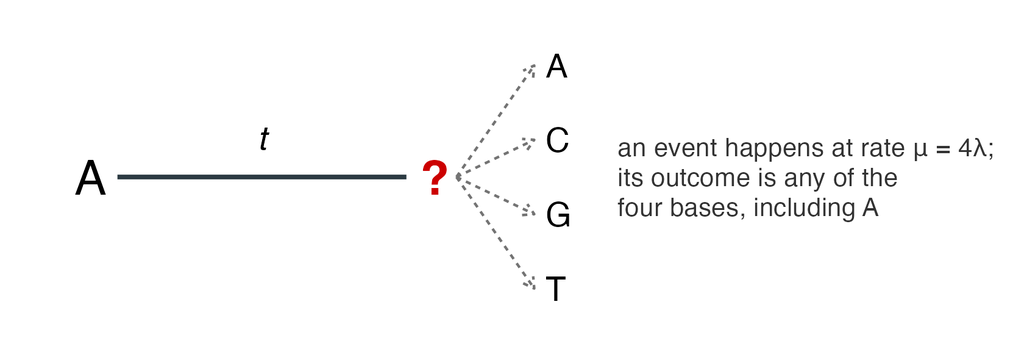

- Let “events” happen at rate $\mu$. Each event draws a new base **uniformly from all four** — so an event can redraw A as A.
- A *specific* change, say A→C, happens at rate $\mu/4$. That’s $\lambda$, so $\mu = 4\lambda$.

## Deriving $P(t)$ for JC69: the Poisson step

The number of events in time $t$ is Poisson with mean $\mu t$:

$$\begin{aligned}
\Pr(\text{no event}) &= e^{-\mu t} \qquad\qquad \Pr(\text{at least one event}) = 1 - e^{-\mu t}\\[4pt]
\Pr(\text{last event drew a T}) &= \tfrac14
\end{aligned}$$

$$\begin{aligned}
P_{AT}(t) &= \tfrac14\left(1 - e^{-\mu t}\right) = \tfrac14 - \tfrac14 e^{-4\lambda t}\\[4pt]
P_{AA}(t) &= \underbrace{e^{-4\lambda t}}_{\text{nothing happened}} + \underbrace{\tfrac14\left(1-e^{-4\lambda t}\right)}_{\text{events, but ended on A}} = \tfrac14 + \tfrac34 e^{-4\lambda t}
\end{aligned}$$

Check: $P_{AA} + 3P_{AT} = 1$. These are $e^{Qt}$ for the JC69 $Q$.

## In branch-length units

Measure a branch by the expected number of **real** substitutions per site, $v$: the rate of *leaving* a base times time, $v = 3\lambda t$. So $4\lambda t = \tfrac43 v$ and

$$P_{ii}(v) = \tfrac14 + \tfrac34 e^{-4v/3}, \qquad P_{ij}(v) = \tfrac14 - \tfrac14 e^{-4v/3}.$$

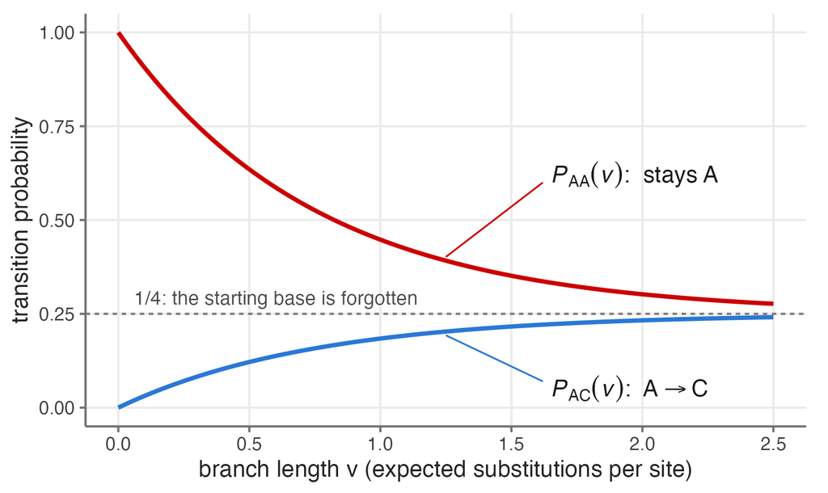

## The model corrects for multiple hits

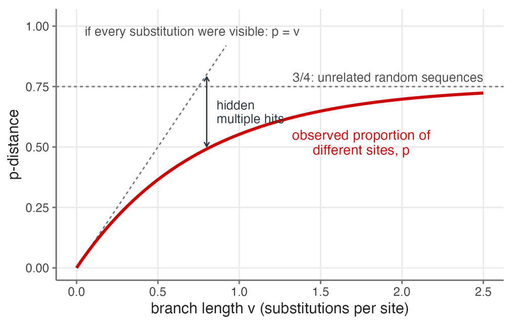

Two sequences separated by a total path length $v$ differ at a proportion

$$p = \tfrac34\left(1 - e^{-4v/3}\right)$$

of sites. Invert it to estimate $v$ from the data, the **JC distance** $d$:

$$d = -\tfrac34\log\!\left(1 - \tfrac43 p\right)$$

The raw proportion $p$ always **underestimates** $v$ once sites have been hit twice.

## HKY85: transitions ≠ transversions

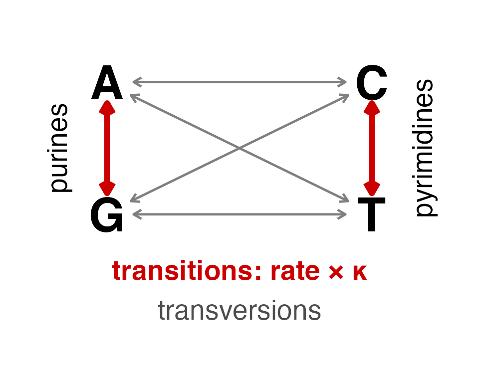

$$Q = \begin{array}{c|cccc}
& A & C & G & T\\ \hline
A & - & \pi_C\beta & \pi_G\beta\kappa & \pi_T\beta\\
C & \pi_A\beta & - & \pi_G\beta & \pi_T\beta\kappa\\
G & \pi_A\beta\kappa & \pi_C\beta & - & \pi_T\beta\\
T & \pi_A\beta & \pi_C\beta\kappa & \pi_G\beta & -
\end{array}$$

- Transitions run $\kappa$ times faster than transversions (Hasegawa, Kishino, and Yano 1985).
- Base frequencies $\pi$ are free.

## GTR: let the data decide

$$Q = \begin{array}{c|cccc}
& A & C & G & T\\ \hline
A & - & \pi_C a\mu & \pi_G b\mu & \pi_T c\mu\\
C & \pi_A a\mu & - & \pi_G d\mu & \pi_T e\mu\\
G & \pi_A b\mu & \pi_C d\mu & - & \pi_T f\mu\\
T & \pi_A c\mu & \pi_C e\mu & \pi_G f\mu & -
\end{array}$$

- Six **exchangeabilities** $a\ldots f$ (five free, one fixed for scale) plus three free base frequencies: **8** parameters (Tavaré 1986).
- Most models in use sit between JC69 and GTR. Classic RAxML uses GTR for DNA; IQ-TREE picks a model for you.
- Amino-acid and codon models exist too, with their own complications.

## A hierarchy of substitution models

Models differ in how much of $Q$ they let vary (base frequencies $\pi$, exchangeabilities):

| Model | Base freqs | Rates | Free $Q$ parameters |
| --- | --- | --- | --- |
| **JC69** | equal | all equal | 0 |
| **K80** | equal | transitions ≠ transversions ($\kappa$) | 1 |
| **HKY85** | free | transitions ≠ transversions ($\kappa$) | 4 |
| **GTR** | free | all six exchangeabilities free | 8 |

Each model is a special case of the one below it: they are **nested**.

## Rate variation among sites

Every model above can add **rate variation**: some sites evolve quickly, others hardly at all.

Even RuBisCO, encoded by *rbcL* — the workhorse gene of early plant phylogenetics — combines a mass of strongly constrained sites with a few residues under **positive selection** in most land-plant lineages (Kapralov and Filatov 2007).

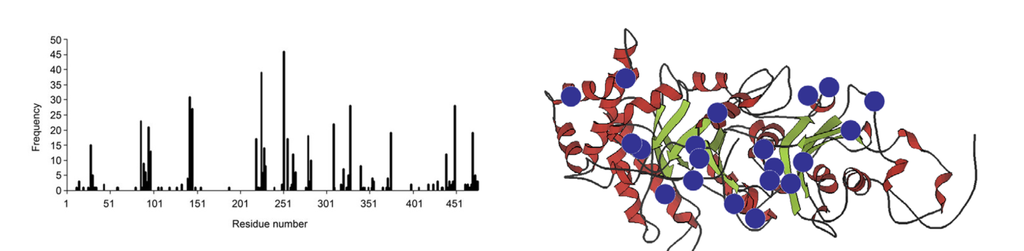

The distribution of sites under selection in *rbcL* and their relevance in the context of a 3-D protein structure. Figs. 1 and 2 from Kapralov and Filatov (2007)

## Approach 1: partition the alignment

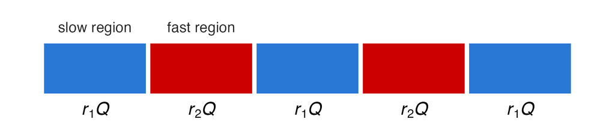

Each region gets its own rate multiplier on the same $Q$. For JC69 in region $k$:

$$P_{ii}(v) = \tfrac14 + \tfrac34 e^{-4 r_k v/3}, \qquad P_{ij}(v) = \tfrac14 - \tfrac14 e^{-4 r_k v/3}$$

- **Pro:** each site’s likelihood is computed once.
- **Con:** the regions must be chosen *a priori*, and rates still vary within them.

## Approach 2: a mixture at every site

Let **every** site have any of $K$ rates, and average (the OR rule) over them. With $K=4$ equally likely rates:

$$L(\theta) = \prod_{h=1}^{N}\left[\tfrac14\Pr(x_h\mid r_1) + \tfrac14\Pr(x_h\mid r_2) + \tfrac14\Pr(x_h\mid r_3) + \tfrac14\Pr(x_h\mid r_4)\right]$$

Here $x_h$ is alignment column $h$. No partitions needed. But where do $r_1,\dots,r_4$ come from?

## Rates from a gamma distribution

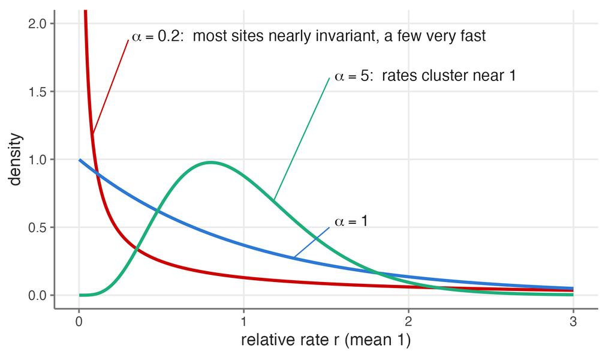

Assume relative rates follow a **gamma distribution** with mean 1 (Yang 1994):

$$r \sim \text{Gamma}(\text{shape}=\alpha,\ \text{rate}=\alpha)$$

- Small $\alpha$ → strong heterogeneity.
- Large $\alpha$ → nearly equal rates.
- One extra parameter: “$+\Gamma$”.

## The discrete gamma

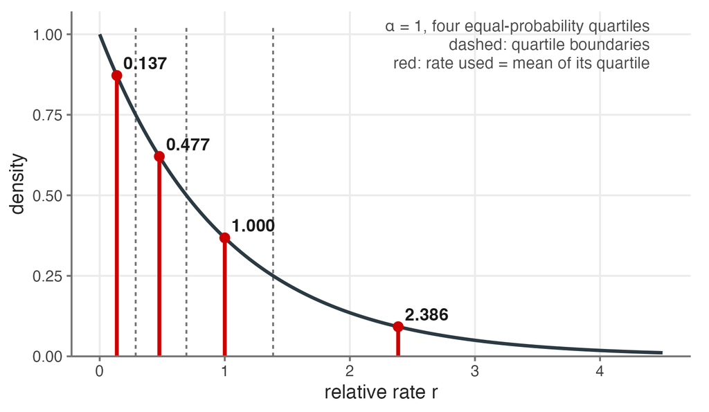

Split the gamma into $K$ equal-probability categories (often 4) and use each category’s **mean** as its rate (Yang 1994).

| $\alpha$ | $r_1$ | $r_2$ | $r_3$ | $r_4$ |
| --- | --- | --- | --- | --- |
| 1 | 0.137 | 0.477 | 1.000 | 2.386 |
| 0.5 | 0.033 | 0.252 | 0.820 | 2.894 |

The rates average to 1.

## Beyond the gamma

- **Free-rate model**: estimate the $K$ rates *and* their weights directly, with no gamma shape assumed (Yang 1995). Usually written $+R_K$ in IQ-TREE.
- Needs enough data to estimate the categories; $+\Gamma$ is still widely used.
- **$+I$**: a proportion of sites that never change.

# Choosing a model

## The Akaike Information Criterion

$$\mathrm{AIC} = 2k - 2\log \hat L$$

- $k$ = number of free parameters; $\hat L$ = the maximum likelihood.
- More parameters always raise $\hat L$; the $2k$ term charges for them (Akaike 1974).
- **Goal:** the best — or least-worst — model among those we tried.

## A true model exists

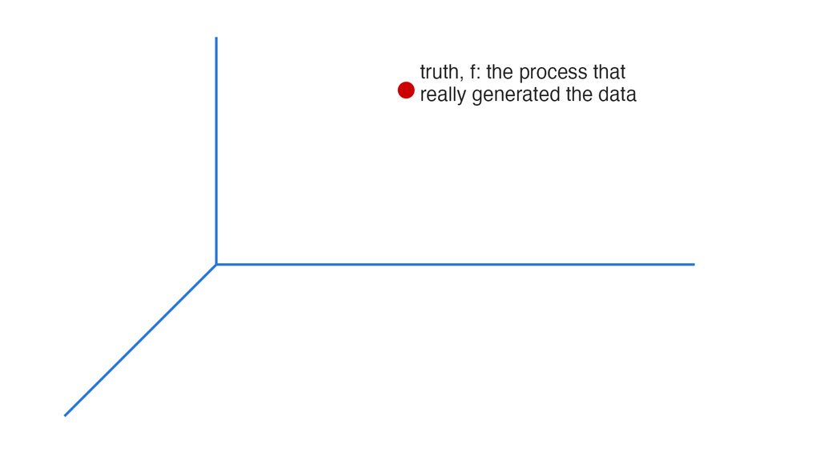

## Our models live in a smaller space

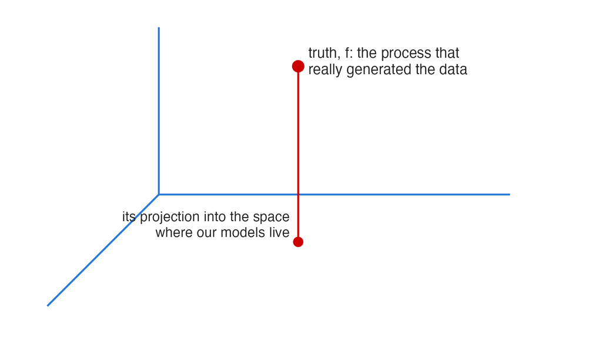

## An approximating model

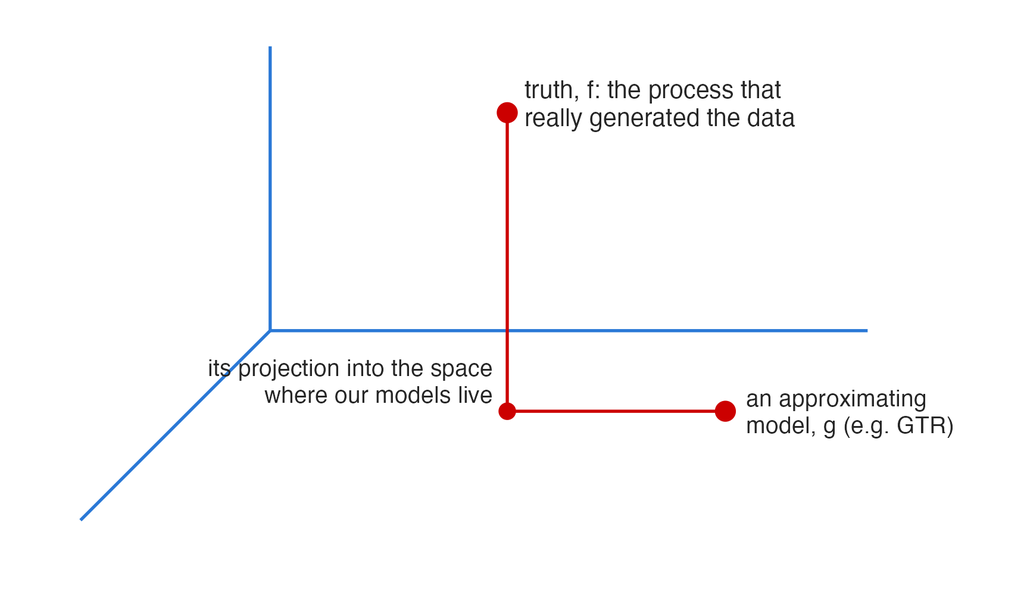